# Introduction à l’analyse des données avec la base iris

## 2.12 Tabplot

Distribution des variables en fonction des espèces

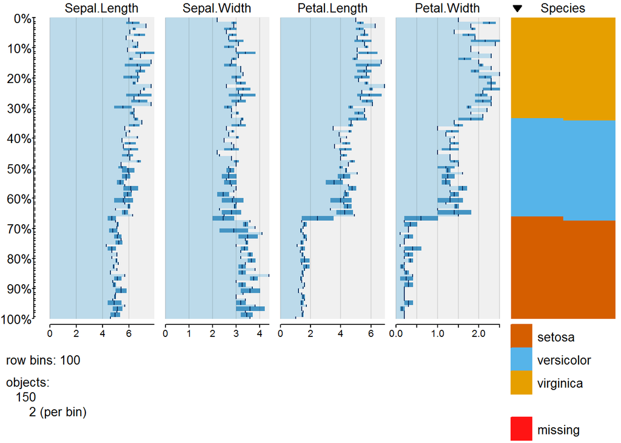

```r
# install.packages("tabplot")
library(tabplot)
tableplot(iris, sortCol="Species")
```

## 2.13 Heatmap

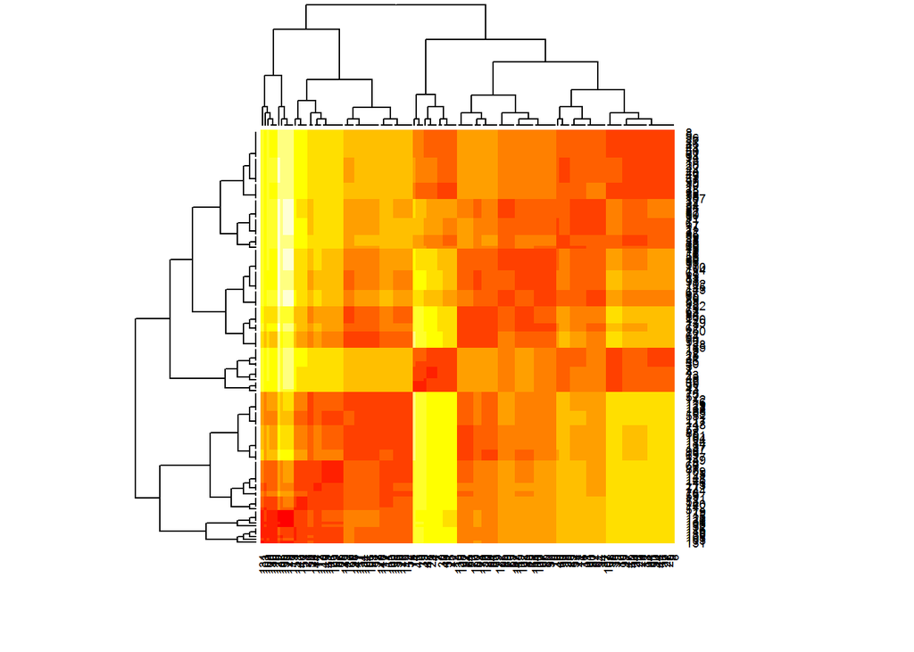

```r
library(ggplot2)
distMatrix <- as.matrix(dist(iris[,1]))
heatmap(distMatrix)
```

## 2.14 Parallel Cordinates

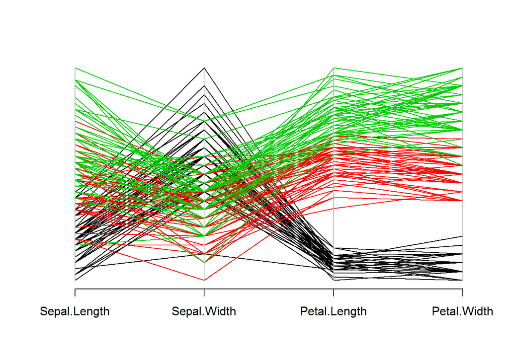

```r
library(MASS)
parcoord(iris[1:4], col=iris$Species)
```

## 2.15 Visualisation de 3 variables

Jusqu’à maintenant, la visualisation est réalisée en dimension 2. Visualiser 3 variables dans l’espace

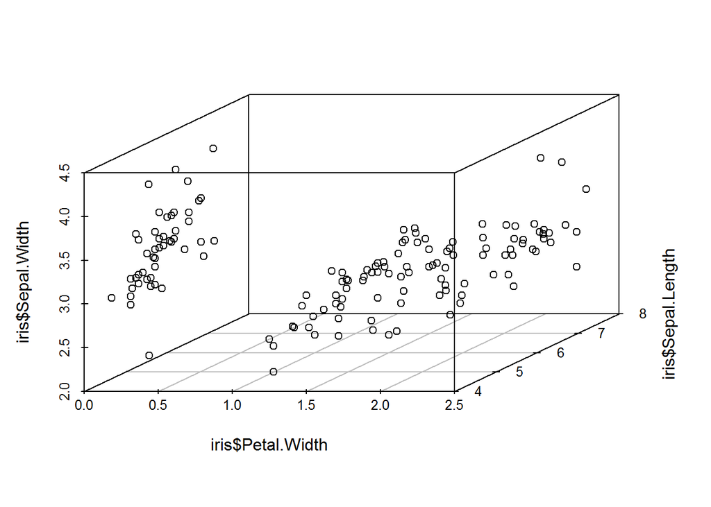

```r
library(scatterplot3d)
scatterplot3d(iris$Petal.Width, iris$Sepal.Length, iris$Sepal.Width)
```

## 2.16 Visualisation de 3 variables interactive

```r
library(threejs)
scatterplot3js(iris$Petal.Width, iris$Sepal.Length, iris$Sepal.Width,color=c("black","steelblue","red")[unclass(iris$Species)])
```

[interactive chart not shown]

## 2.17 Visualisation de 3 variables en dim 2

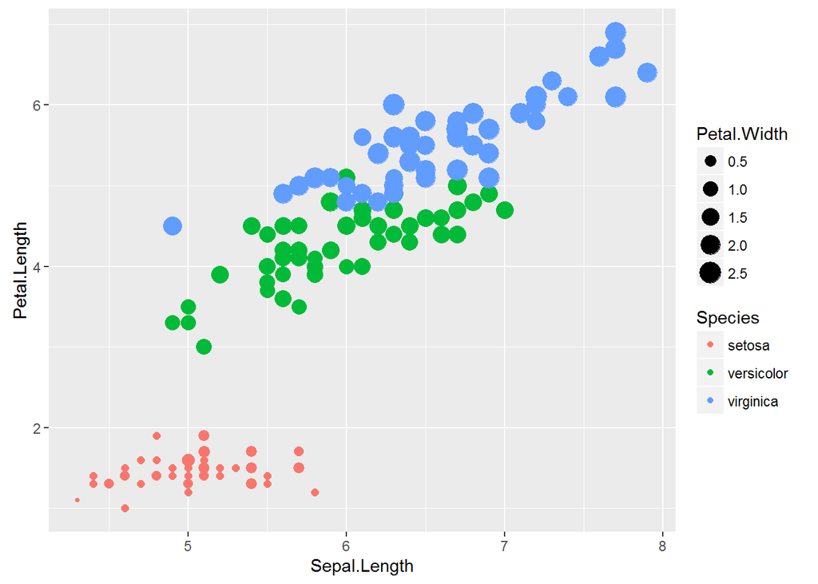

```r
library(ggplot2)
qplot(Sepal.Length,Petal.Length, data=iris,color=Species,size=Petal.Width)
```

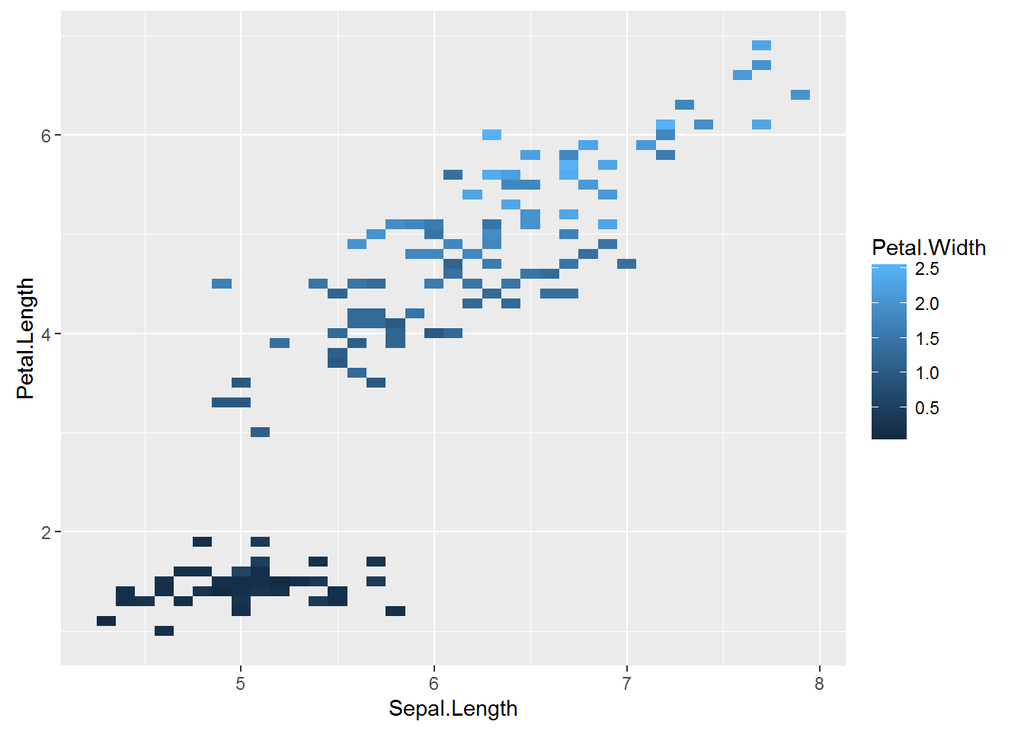

```r
ggplot(iris, aes(Sepal.Length, Petal.Length, fill = Petal.Width)) + geom_tile()
```

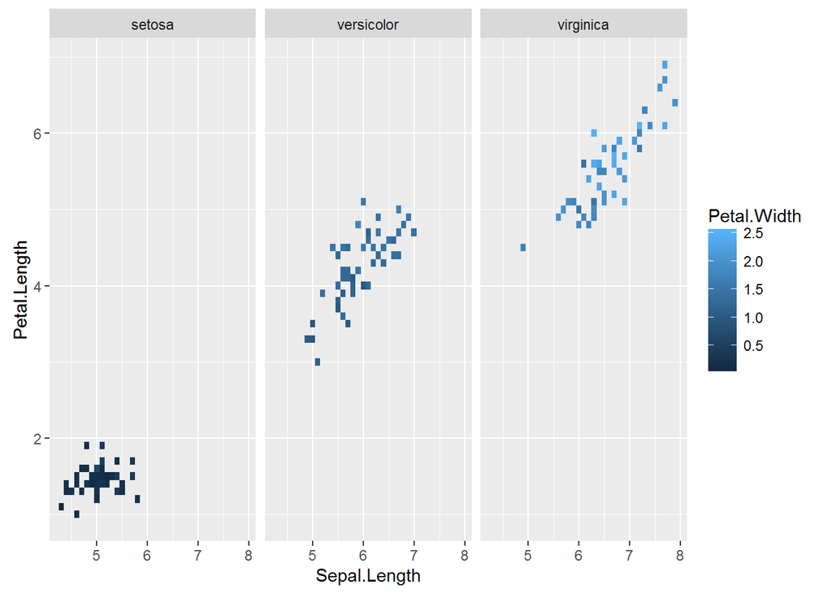

```r
last_plot() + facet_wrap(~ Species)
```

# 3 Techinques d’apprentissage automatique

## 3.1 Exploration (pour aller plus loin)

Dans le graphique en 3D interactif, on voit qu’on peut tourner les points dans l’espace. Selon le point de vue, on distingue plus ou moins mieux les 3 classes. L’idée d’analyse en composantes principales est de choisir un repère de façon à augmenter la variance inter classe.

lda permet de mieux distinguer les différentes classes.

## 3.2 Classification non supervisée - k-means

```r
iris2 <- iris
iris2$Species <- NULL
(kmeans.result <- kmeans(iris2, 3))
```

```
## K-means clustering with 3 clusters of sizes 38, 62, 50
##
## Cluster means:
##   Sepal.Length Sepal.Width Petal.Length Petal.Width
## 1     6.850000    3.073684     5.742105    2.071053
## 2     5.901613    2.748387     4.393548    1.433871
## 3     5.006000    3.428000     1.462000    0.246000
##
## Clustering vector:
##   [1] 3 3 3 3 3 3 3 3 3 3 3 3 3 3 3 3 3 3 3 3 3 3 3 3 3 3 3 3 3 3 3 3 3 3 3
##  [36] 3 3 3 3 3 3 3 3 3 3 3 3 3 3 3 2 2 1 2 2 2 2 2 2 2 2 2 2 2 2 2 2 2 2 2
##  [71] 2 2 2 2 2 2 2 1 2 2 2 2 2 2 2 2 2 2 2 2 2 2 2 2 2 2 2 2 2 2 1 2 1 1 1
## [106] 1 2 1 1 1 1 1 1 2 2 1 1 1 1 2 1 2 1 2 1 1 2 2 1 1 1 1 1 2 1 1 1 1 2 1
## [141] 1 1 2 1 1 1 2 1 1 2
##
## Within cluster sum of squares by cluster:
## [1] 23.87947 39.82097 15.15100
##  (between_SS / total_SS =  88.4 %)
##
## Available components:
##
## [1] "cluster"      "centers"      "totss"        "withinss"
## [5] "tot.withinss" "betweenss"    "size"         "iter"
## [9] "ifault"
```

### 3.2.1 Classification non supervisée - k-means plot

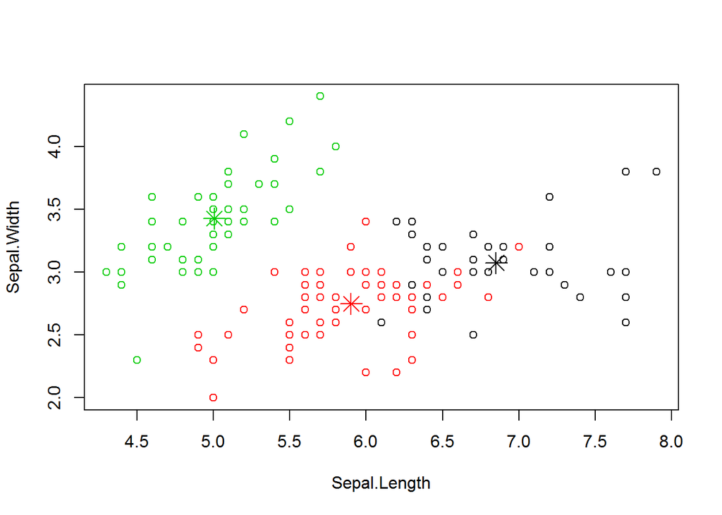

```r
plot(iris2[c("Sepal.Length", "Sepal.Width")], col = kmeans.result$cluster)
points(kmeans.result$centers[,c("Sepal.Length", "Sepal.Width")], col = 1:3,pch = 8, cex=2)
```

### 3.2.2 Classification non supervisée - k-means prédiction

```r
table(iris$Species, kmeans.result$cluster)
```

```
##
##               1  2  3
##   setosa      0  0 50
##   versicolor  2 48  0
##   virginica  36 14  0
```

## 3.3 Arbre de décision

Dans la base iris, on sait que trois espèces de fleurs sont représentées avec certaines caractéristiques (4 variables). La question qu’on se pose, c’est si une nouvelle observation arrive (avec les valeurs des 4 mesures), comment peut-on savoir à quelle espace la fleur appartient ?

### 3.3.1 Arbre de décision - construction

- Créer deux bases : apprentisage et test
- Construire un arbre de décision sur la base d’apprentissage avec la librairie `party`, et la fonction `ctree(variable à expliquer ~ variable 1 + variable 2)`
- Afficher l’arbre avec `print` et `plot`

```r
ind <- sample(2, nrow(iris), replace=TRUE, prob=c(0.7, 0.3))
trainData <- iris[ind==1,]
testData <- iris[ind==2,]
library(party)
myFormula <- Species ~ Sepal.Length + Sepal.Width + Petal.Length + Petal.Width
iris_ctree <- ctree(myFormula, data=trainData)
```

### 3.3.2 Arbre de décision - Affichage

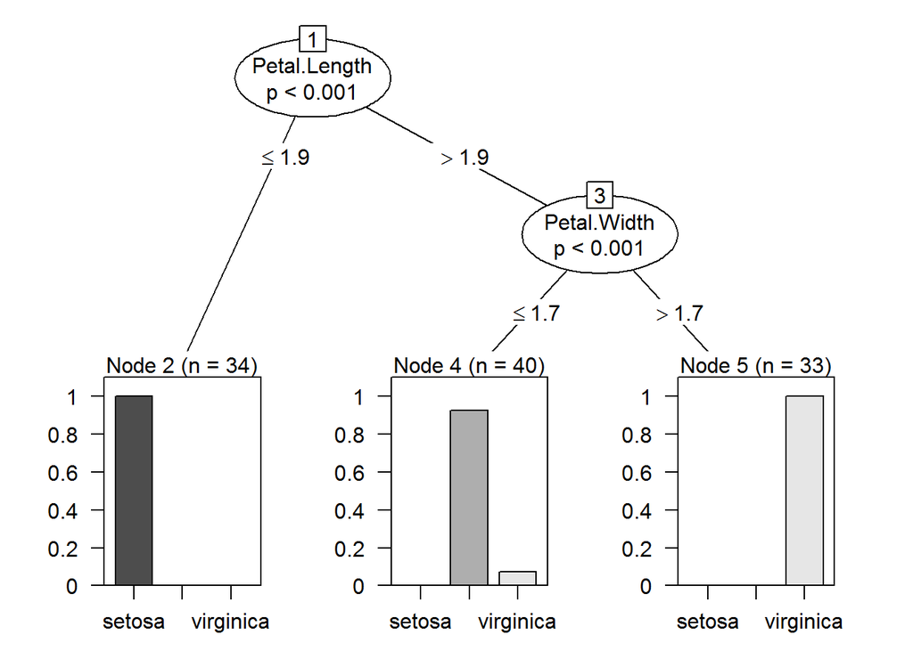

```r
plot(iris_ctree)
```

```r
print(iris_ctree)
```

```
##
##   Conditional inference tree with 3 terminal nodes
##
## Response:  Species
## Inputs:  Sepal.Length, Sepal.Width, Petal.Length, Petal.Width
## Number of observations:  107
##
## 1) Petal.Length <= 1.9; criterion = 1, statistic = 99.746
##   2)*  weights = 34
## 1) Petal.Length > 1.9
##   3) Petal.Width <= 1.7; criterion = 1, statistic = 52.247
##     4)*  weights = 40
##   3) Petal.Width > 1.7
##     5)*  weights = 33
```

### 3.3.3 Arbre de décision - Exploitation

- Quelle est la varialbe la plus explicative ?
- Quelle est la précision de prédiction ?
- Combien a-t-on de branches et de feuilles ?

### 3.3.4 Arbre de décision - table de confusion

```r
table(predict(iris_ctree), trainData$Species)
```

```
##
##              setosa versicolor virginica
##   setosa         34          0         0
##   versicolor      0         37         3
##   virginica       0          0        33
```

Calculer les taux de faux positif, faux négatifs, taux d’erreur

### 3.3.5 Arbre de décision - Prédiction

```r
testPred <- predict(iris_ctree, newdata = testData)
table(testPred, testData$Species)
```

```
##
## testPred     setosa versicolor virginica
##   setosa         16          0         0
##   versicolor      0         12         2
##   virginica       0          1        12
```

Calculer les taux de faux positif, faux négatifs, taux d’erreur Pour aller plus loin : créer une boucle pour calculer un taux moyen d’erreur Autre pacakge `rpart` pour construire un arbre de décision

## 3.4 Random Forest - Introduction

Si on n’a pas fixé le `seed()` on voit que les échantillons d’apprentissage et de test sont choisis de façon aléatoire. La bagging permet de réaliser ces opérations automatiques. De plus, on peut aussi choisir les variables. Les deux randomisations ensemble, on obtient une forêt aléatoire.

```r
library(randomForest)
rf <- randomForest(Species ~ ., data=trainData, ntree=100, proximity=TRUE)
```

## 3.5 Random Forest - Analyse

```r
table(predict(rf), trainData$Species)
```

```
##
##              setosa versicolor virginica
##   setosa         34          0         0
##   versicolor      0         36         3
##   virginica       0          1        33
```

```r
print(rf)
```

```
##
## Call:
##  randomForest(formula = Species ~ ., data = trainData, ntree = 100,      proximity = TRUE)
##                Type of random forest: classification
##                      Number of trees: 100
## No. of variables tried at each split: 2
##
##         OOB estimate of  error rate: 3.74%
## Confusion matrix:
##            setosa versicolor virginica class.error
## setosa         34          0         0  0.00000000
## versicolor      0         36         1  0.02702703
## virginica       0          3        33  0.08333333
```

```r
attributes(rf)
```

```
## $names
##  [1] "call"            "type"            "predicted"
##  [4] "err.rate"        "confusion"       "votes"
##  [7] "oob.times"       "classes"         "importance"
## [10] "importanceSD"    "localImportance" "proximity"
## [13] "ntree"           "mtry"            "forest"
## [16] "y"               "test"            "inbag"
## [19] "terms"
##
## $class
## [1] "randomForest.formula" "randomForest"
```

```r
importance(rf)
```

```
##              MeanDecreaseGini
## Sepal.Length         7.221444
## Sepal.Width          1.971294
## Petal.Length        31.828355
## Petal.Width         29.547038
```

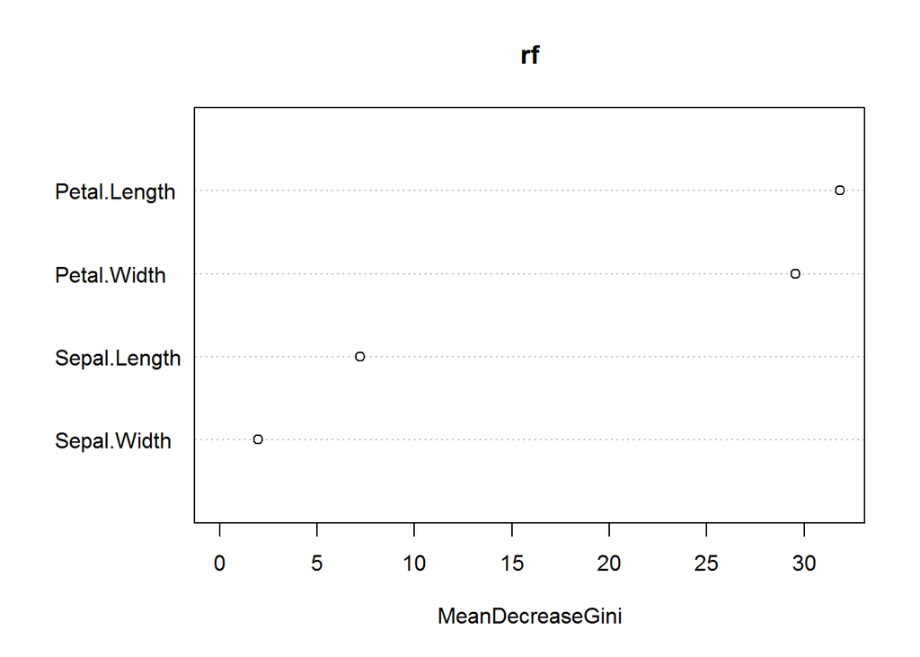

```r
varImpPlot(rf)
```

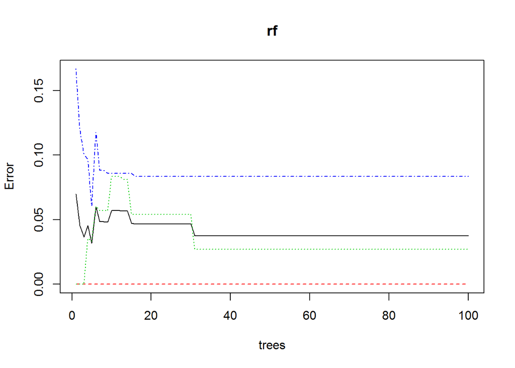

```r
plot(rf)
```

### 3.5.1 Random Forest - Prédiction 1

```r
irisPred <- predict(rf, newdata=testData)
table(irisPred, testData$Species)
```

```
##
## irisPred     setosa versicolor virginica
##   setosa         16          0         0
##   versicolor      0         11         0
##   virginica       0          2        14
```

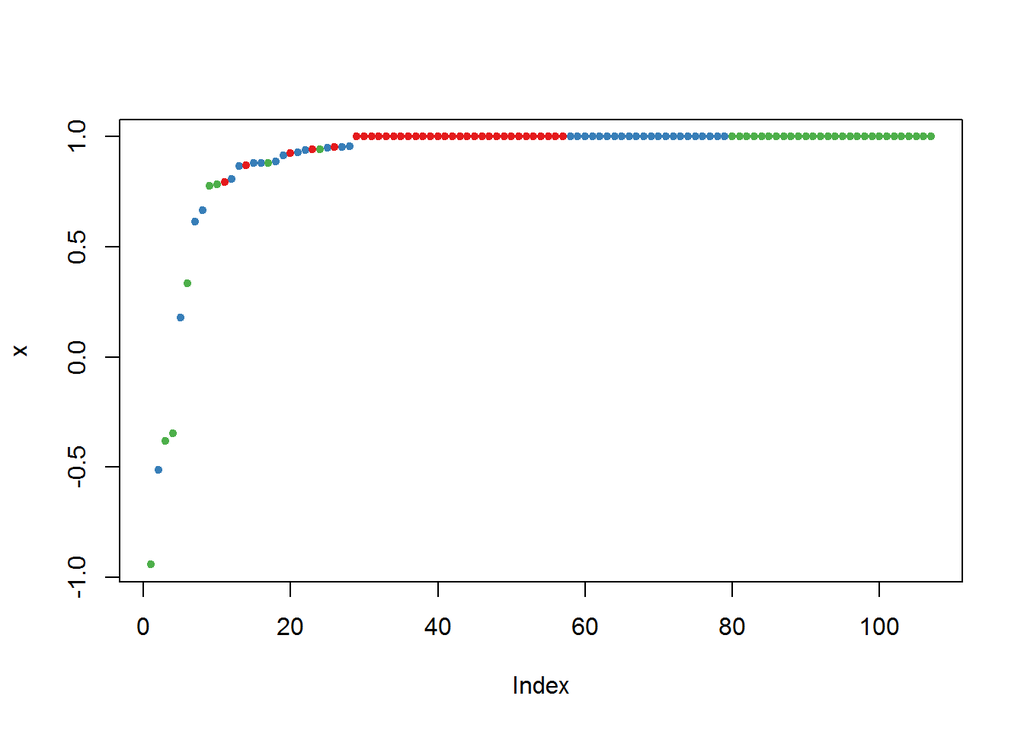

```r
plot(margin(rf, testData$Species))
```